# The Monte Carlo method

# Ex. in Chapter 4 in Hoff (2009). A first course in Bayesian statistical methods. Springer

The Monte Carlo method

$\bf Y_1$ is the vector of the numbers of children of the $n_1$ women WITHOUT college degrees

$\bf Y_2$ is the vector of the numbers of children of the $n_2$ women WITH college degrees

We assume $\bf Y_1$ and $\bf Y_2$ conditionally to $(\theta_1,\theta_2$) independent and
$$Y_{ij}|\theta_j \stackrel{iid}\sim Poi(\theta_j), i=1,\ldots,n_j, \quad
j=1,2$$
A priori, the components of the two vectors are iid from Poisson with parameter theta_1 and theta_2, respectively
$$\theta_1,\theta_2 \stackrel{iid}\sim gamma(\alpha,\beta)$$
with $E(\theta_j)=\alpha/\beta=2$ and $Var(\theta_j)=\alpha/\beta^2=2$ for $j=1,2$, so that $\alpha=2$, $\beta=1$

The POSTERIOR of $(\theta_1,\theta_2)$:
$$gamma(\alpha+\sum_i y_{i1},\beta+n_1)\times
gamma(\alpha+\sum_i y_{i2},\beta+n_2)=gamma(219,112)\times gamma(68,45)$$

> NOTATION: MC standard error = sqrt(variance of the estimator of the parameter of interest)

Let us plot the marginal posterior of $\theta_2$ via the Monte Carlo method; we use 3 different groups of iid draws from the posterior of $\theta_2$

```r
set.seed(1)
a<-68 ; b<-45
set.seed(1)
theta.support<-seq(0,3,length=100)
## 3 different groups of iid draws from the posterior of theta_2
theta.sim10<-rgamma(10,a,b)# iid sample of size M=10 from the gamma(a,b)
theta.sim100<-rgamma(100,a,b) #size M=100
theta.sim1000<-rgamma(1000,a,b) #size M=1000
```

Plot of the histogram and *kernel density estimate* for the 3 groups of iid draws

```r
#par(mar=c(3,3,.25,1),mgp=c(1.75,.75,0))
par(mfrow=c(2,3))
xlim<-c(.75,2.25)
ylim=c(0,2.5)
lty=1

hist( theta.sim10, prob=T,xlim=xlim,ylim=ylim,xlab="",main="",ylab="")
lines(theta.support,dgamma(theta.support,a,b),col="gray",lwd=2,lty=lty)
```

```r
text(2.1,2.25,expression(paste(italic(M),"=10",sep="")))

hist( theta.sim100, prob=T,xlim=xlim,ylim=ylim,xlab="",main="" ,ylab="")
```

```r
lines(theta.support,dgamma(theta.support,a,b),col="gray",lwd=2,lty=lty)
text(2.1,2.25,expression(paste(italic(M),"=100",sep="")))
```

```r
hist( theta.sim1000, prob=T,xlim=xlim,ylim=ylim,xlab="",main="" ,ylab="")
lines(theta.support,dgamma(theta.support,a,b),col="gray",lwd=2,lty=lty)
```

```r
text(2.1,2.25,expression(paste(italic(M),"=1000",sep="")))


plot(density(theta.sim10),xlim=xlim,ylim=ylim,xlab=expression(theta),main="",ylab="")
```

```r
lines(theta.support,dgamma(theta.support,a,b),col="gray",lwd=2,lty=lty)

plot(density(theta.sim100),xlim=xlim,ylim=ylim,xlab=expression(theta),main="",ylab="")
```

```r
lines(theta.support,dgamma(theta.support,a,b),col="gray",lwd=2,lty=lty)

plot(density(theta.sim1000),xlim=xlim,ylim=ylim,xlab=expression(theta),main="",ylab="")
```

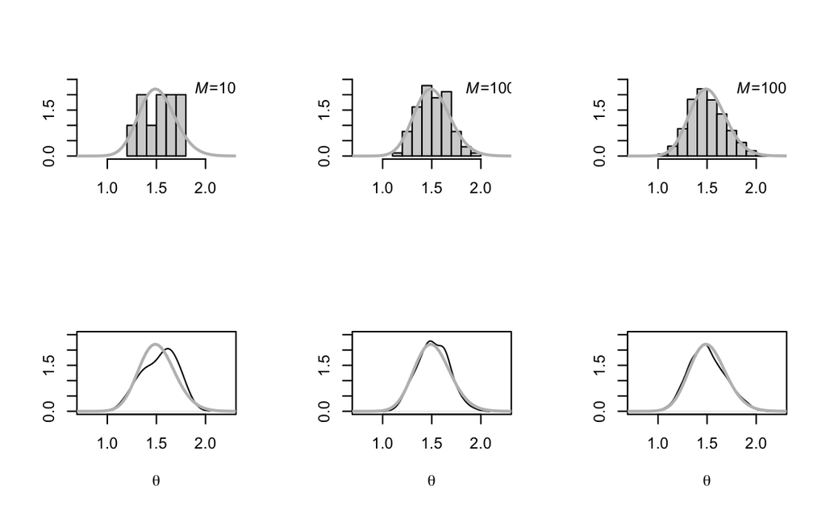

```r
lines(theta.support,dgamma(theta.support,a,b),col="gray",lwd=2,lty=lty)
```

Note that the kernel density estimator, a smoothed version of the histogram, is obtained with the command “density”

Monte Carlo computation of the posterior mean of $\theta_2$: $\theta_2 \sim gamma(\alpha+\sum_i y_{i2}=68, \beta+n_2=45)$

```r
set.seed(1)
a<-2  ; b<-1
sy<-66; n<-44

theta.sim10<-rgamma(10,a+sy,b+n)
theta.sim100<-rgamma(100,a+sy,b+n)
theta.sim1000<-rgamma(1000,a+sy,b+n)
```

Posterior mean for $M=10,100,1000$

$M=10$:

```r
#(a+sy)/(b+n)# exact value
cat(sprintf("exact value of the posterior mean: %f\n", (a+sy)/(b+n)))
```

```
exact value of the posterior mean: 1.511111
```

```r
mean(theta.sim10) # MC estimate and MC standard error for 10 draws
```

```
[1] 1.532794
```

```r
sqrt(var(theta.sim10)/10)
```

```
[1] 0.05410572
```

```r
# Probability that the absolute value of the error is larger than c
c=0.01
2*(1-pnorm(c/(sqrt(var(theta.sim10)/10))))
```

```
[1] 0.8533676
```

$M=100$:

```r
mean(theta.sim100)  #  MC estimate and MC standard error for 100 draws
```

```
[1] 1.513947
```

```r
sqrt(var(theta.sim100)/100)
```

```
[1] 0.01556436
```

```r
2*(1-pnorm(c/(sqrt(var(theta.sim100)/100))))
```

```
[1] 0.5205529
```

$M=1000$:

```r
mean(theta.sim1000)  #  MC estimate and MC standard error for 1000 draws
```

```
[1] 1.501015
```

```r
sqrt(var(theta.sim1000)/1000)
```

```
[1] 0.005886511
```

```r
2*(1-pnorm(c/(sqrt(var(theta.sim1000)/1000))))
```

```
[1] 0.08935701
```

MC computation of the posterior distribution function at 1.75

```r
pgamma(1.75,a+sy,b+n) #exact value
```

```
[1] 0.8998286
```

The MC estimate is the relative frequency of the simulated draws that are smaller than 1.75

```r
mean( theta.sim10<1.75)   # I'm using 10 MC draws
```

```
[1] 0.9
```

```r
mean( theta.sim100<1.75)  # 100 draws
```

```
[1] 0.94
```

```r
mean( theta.sim1000<1.75) # 1000 draws
```

```
[1] 0.899
```

Posterior 95% credible interval, given by two symmetric quantiles

```r
qgamma(c(.025,.975),a+sy,b+n)
```

```
[1] 1.173437 1.890836
```

```r
quantile( theta.sim10, c(.025,.975))
```

```
    2.5%    97.5%
1.260291 1.750068
```

```r
quantile( theta.sim100, c(.025,.975))
```

```
    2.5%    97.5%
1.231646 1.813752
```

```r
quantile( theta.sim1000, c(.025,.975))
```

```
    2.5%    97.5%
1.180194 1.892473
```

Monte Carlo approximations as the sample size increases

```r
par(mfrow=c(1,3),mar=c(2.75,2.75,.5,.5),mgp=c(1.70,.70,0))

set.seed(1)
a<-2   ; b<-1
sy<-66 ; n<-44

nsim<-1000
theta.sim<-rgamma(nsim,a+sy,b+n)

#cumulative mean
#?cumsum
cmean<-cumsum(theta.sim)/(1:nsim)
cvar<- cumsum(theta.sim^2)/(1:nsim) - cmean^2
ccdf<- cumsum(theta.sim<1.75)/ (1:nsim)
cq<-NULL
for(j in 1:nsim){ cq<-c(cq,quantile(theta.sim[1:j],probs=0.975)) }

sseq<- c(1,(1:100)*(nsim/100))
cmean<-cmean[sseq]
cq<-cq[sseq]
ccdf<-ccdf[sseq]
```

Plots ofthe MC estimates of the mean, the df at 1.75, the CI as the sample size M increases

REMARK: there is no monotonicity!

```r
par(mfrow=c(1,3),mar=c(2.75,2.75,.5,.5),mgp=c(1.70,.70,0))
plot(sseq,cmean,type="l",xlab="# of Monte Carlo samples",ylab="cumulative mean",
     col="black")
abline(h= (a+sy)/(b+n),col="gray",lwd=2)
```

```r
plot(sseq,ccdf,type="l",xlab="# of Monte Carlo samples",ylab="cumulative cdf at 1.75",col="black")
abline(h= pgamma(1.75,a+sy,b+n),col="gray",lwd=2)
```

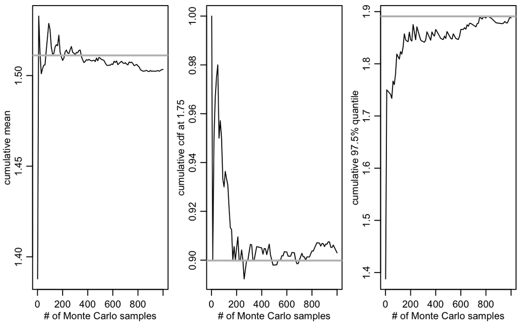

```r
plot(sseq,cq,type="l",xlab="# of Monte Carlo samples",ylab="cumulative 97.5% quantile",col="black")
abline(h= qgamma(.975,a+sy,b+n),col="gray",lwd=2)
```

> MC computation of the posterior probability that $\theta_1>\theta_2$

```r
set.seed(1)
a<-2 ; b<-1
sy1<-217 ;  n1<-111
sy2<-66  ;  n2<-44

a+sy1; b+n1
```

```
[1] 219
[1] 112
```

```r
a+sy2; b+n2
```

```
[1] 68
[1] 45
```

MC sample of size $M=10000$ from the joint posterior

```r
theta1.mc<-rgamma(10000,a+sy1, b+n1)
theta2.mc<-rgamma(10000,a+sy2, b+n2)
```

The probability is estimated by the number of times in the sequence $\{(\theta_1^{(j)},\theta_2^{(j)}),\ j=1,2,...,M\}$ the first component is $>$ than the second, divided by the total number of simulations $M$

```r
mean(theta1.mc>theta2.mc) # this prop is equal to the prob that theta1  is larger or EQUAL to theta2, since (theta1,theta2)  has an ABSOL CONT posterior distr
```

```
[1] 0.9708
```

As an alternative, I can compute the posterior distribution of theta1/theta2.

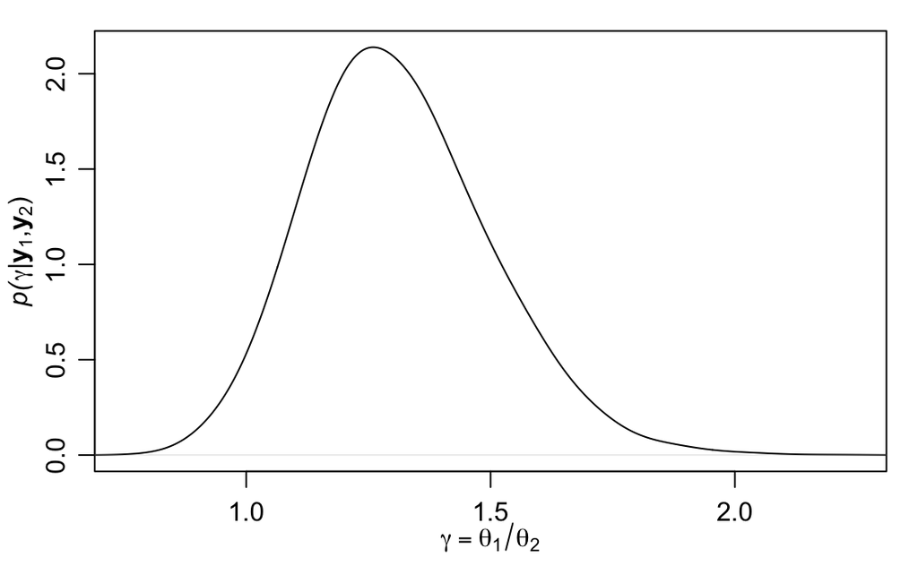

```r
par(mar=c(3,3,1,1),mgp=c(1.75,.75,0))
par(mfrow=c(1,1))
plot(density(theta1.mc/theta2.mc,adj=2),main="",xlim=c(.75,2.25),
xlab=expression(gamma==theta[1]/theta[2]),
ylab=expression(paste(italic("p("),gamma,"|",bold(y[1]),",",bold(y[2]),")",
   sep="")) )
```

> COMPUTATION of PREDICTIVE DISTRIBUTIONS

theta1.mc is a vector of size 10thousand from the posterior distribution of $\theta_1$

```r
y1.mc<-rpois(10000,theta1.mc) #simulate ALL AT ONCE 10K independent (but **not identically distributed**) values from Pois($\theta1_j$), $j=1,\ldots,10K$
y2.mc<-rpois(10000,theta2.mc)

mean(y1.mc>y2.mc)  #it is about 0.48
```

```
[1] 0.4846
```

```r
mean(y1.mc==y2.mc)  # it's about 0.21 ;
```

```
[1] 0.2108
```

```r
                    #### hence the posterior predictive prob. that Y_1 is larger or equal to Y_2 is 0.69

mean(y1.mc<y2.mc)   #around 0.3
```

```
[1] 0.3046
```

Predictive of $Y_{n_1+1, 1}-Y_{n_2+1, 2}$:

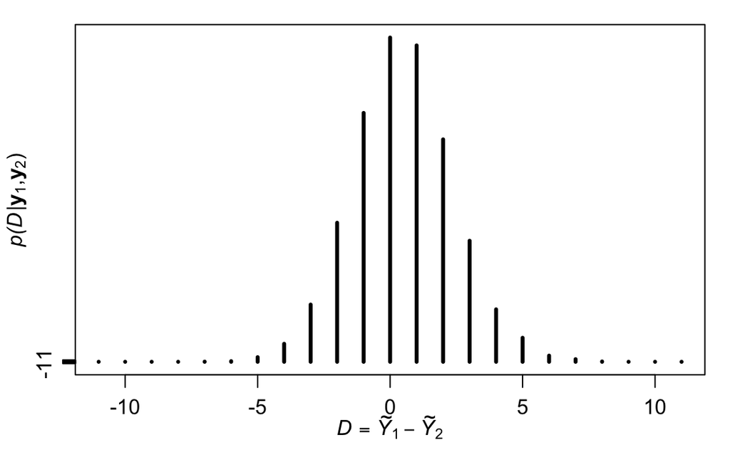

```r
par(mar=c(3,3,1,1),mgp=c(1.75,.75,0))

diff.mc<-y1.mc-y2.mc

ds<- -11:11
plot(ds,(table(c(diff.mc,ds))-1)/length(diff), type="h",lwd=3,
    xlab=expression(italic(D==tilde(Y)[1]-tilde(Y)[2])),
  ylab=expression(paste(italic("p(D"),"|",bold(y[1]),",",bold(y[2]),")",sep="")))
```

> MC marginal posteriors of $\theta_1$ and $\theta_2$:

```r
par(mfrow=c(1,2))
plot(theta1.mc,theta2.mc)
plot(density(theta1.mc),xlim=c(0.5,3.5), ylim=c(0,4),lwd=2,main='posteriors of theta1 e theta2' )
```

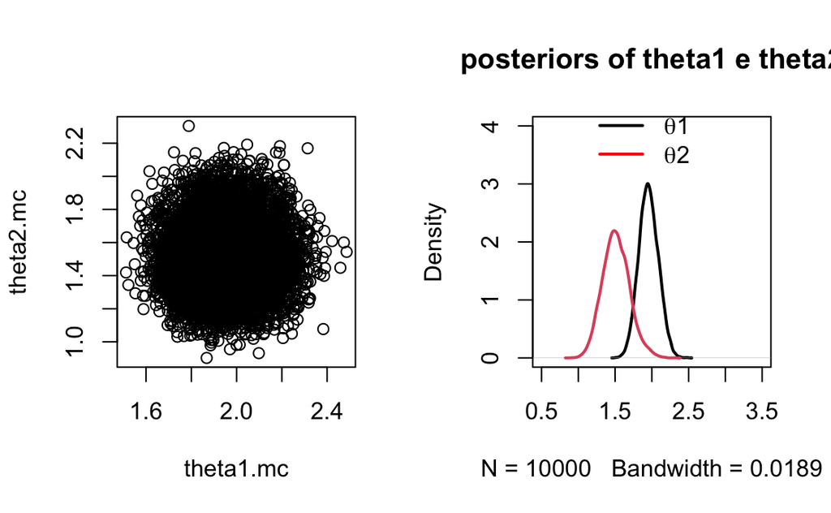

```r
lines(density(theta2.mc),main="",xlim=c(0.5,3.5),   lwd=2, col=2)
legend(1,4.5,legend=c(
    expression(paste(theta,"1",sep="")),
    expression(paste(theta,"2",sep="")) ),
     lwd=c(2,2),
    col=c('black','red') ,bty="n")
```

In this case we know the exact marginal posterior predictive disbributions - negative binomial:

```r
par(mfrow=c(1,2))
a+sy1; (b+n1)/(1+b+n1)  #hypeparameters of the exact marginal posterior predictive of Y_1
```

```
[1] 219
[1] 0.9911504
```

```r
a+sy2; (b+n2)/(1+b+n2)  #hypeparameters of the exact marginal posterior predictive of Y_2
```

```
[1] 68
[1] 0.9782609
```

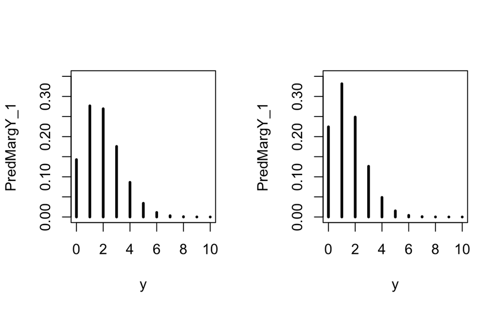

```r
ds=seq(0,10)
plot(ds,dnbinom(ds,a+sy1, (b+n1)/(1+b+n1)), type="h",lwd=3,xlab='y', ylab='PredMargY_1',ylim=c(0,0.35))
plot(ds,dnbinom(ds,a+sy2, (b+n2)/(1+b+n2)), type="h",lwd=3,xlab='y', ylab='PredMargY_1',ylim=c(0,0.35))
```

rmarkdown::render(“your_file.Rmd”, output_format = “html_document”)